# Task 3: Fit the Models

11/16/2022

```r
rm(list=ls())
library(data4led)
bulb <- led_bulb(1,seed = 6154)

t <- bulb$hours
y <- bulb$percent_intensity

f2 <- function(x,a0=0,a1=0,a2=1){ a0 + a1*x + a2*x^2 }
f3 <- function(x,a1=0,a2=1){ (100-a1) + a1*exp(-a2*x) }
f4 <- function(x,a0=0,a1=0,a2=1){a0+a1*x+a2*log(0.005*x+1)}
f5 <- function(x,a0=100,a1=0,a2=1){ (a0 + a1*x)*exp(-a2*x) }

x <- seq(-10,80001,2)
y0 <- f2(x,a0=100,a1=0,a2=0)
y1 <- f2(x,a0=100,a1=5e-4,a2=0)
y2 <- f2(x,a0=100,a1=.95e-3,a2=-1.7e-7)
y3 <- f3(x,a1=-1.3,a2=0.00114)
y4 <- f4(x,a0=100,a1=-2.4e-4,a2=0.7)
y5 <- f5(x,a0=100,a1=6e-3,a2=5.05e-5)
```

The equations used to see the intensity of time are not completely accurate; however, each graph gives a good assumption and visual on the lifetime of the bulbs over time.

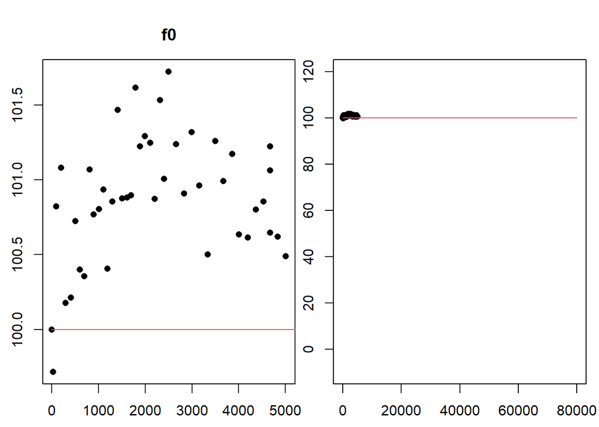

```r
par(mfrow=c(1,2),mar=c(2,2,3,0.25),oma=rep(0.5,4))
plot(t,y,xlab="Hour ", ylab="Intensity(%) ", pch=16,main='f0')
lines(x,y0,col=2)
plot(t,y,xlab="Hour ", ylab="Intensity(%) ", pch=16, xlim = c(-10,80000),ylim = c(-10,120))
lines(x,y0,col=2)
```

We can see from graph f0 that the intensity of the bulbs stay at a constant intensity of 100% at its entire life. This would mean that the light bulbs life is infinite and stays at the same intensity for its whole life.

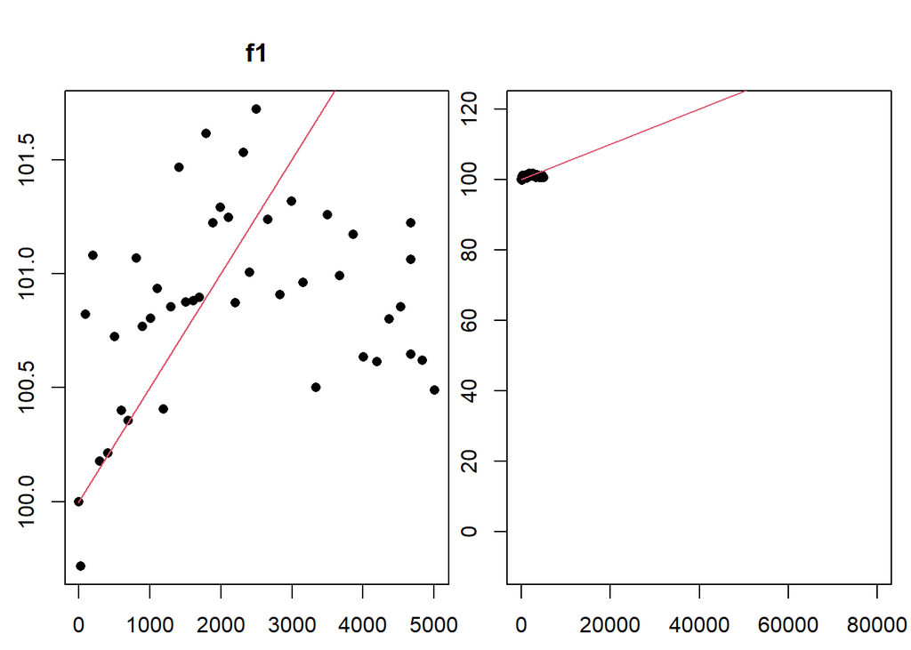

```r
par(mfrow=c(1,2),mar=c(2,2,3,0.25),oma=rep(0.5,4))
plot(t,y,xlab="Hour ", ylab="Intensity(%) ", pch=16,main='f1')
lines(x,y1,col=2)
plot(t,y,xlab="Hour ", ylab="Intensity(%) ", pch=16, xlim = c(-10,80000),ylim = c(-10,120))
lines(x,y1,col=2)
```

We can see from graph f1 that the light bulbs intensity is constant and continually grows. This means tat the light bulbs intensity grow over time and the time-time is infinite.

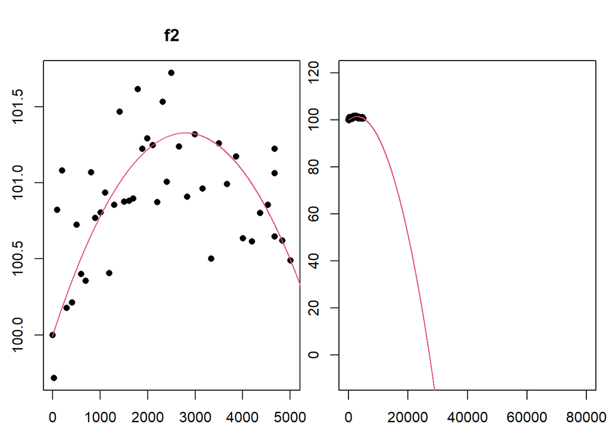

```r
par(mfrow=c(1,2),mar=c(2,2,3,0.25),oma=rep(0.5,4))
plot(t,y,xlab="Hour ", ylab="Intensity(%) ", pch=16,main='f2')
lines(x,y2,col=2)
plot(t,y,xlab="Hour ", ylab="Intensity(%) ", pch=16, xlim = c(-10,80000),ylim = c(-10,120))
lines(x,y2,col=2)
```

We can see in graph f2 that the light intensity grows to a max of 101.3 and then the intensity starts to die. The life of the light reaches zero around 30,000 hours. Knowing this, this means that if you were to leave a light on without turning it off, the light would last about 3.5 years.

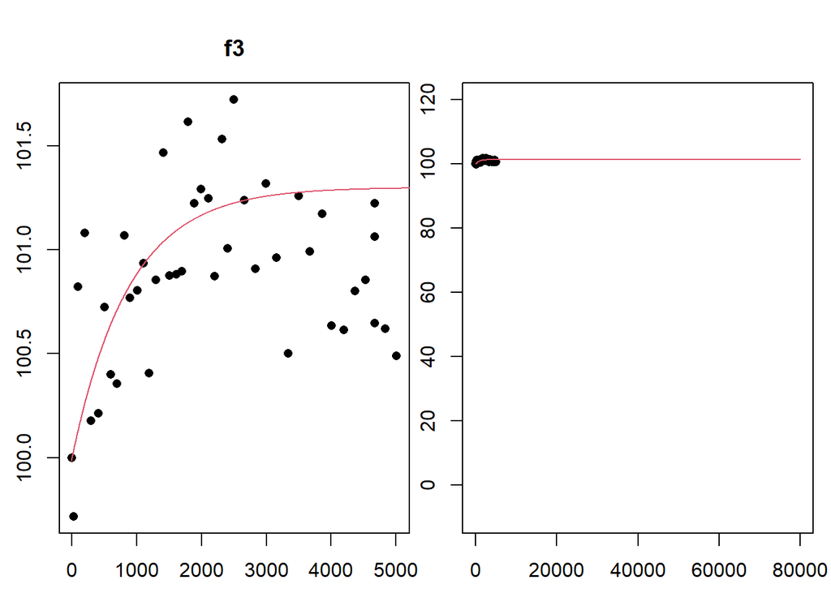

```r
par(mfrow=c(1,2),mar=c(2,2,3,0.25),oma=rep(0.5,4))
plot(t,y,xlab="Hour ", ylab="Intensity(%) ", pch=16,main='f3')
lines(x,y3,col=2)
plot(t,y,xlab="Hour ", ylab="Intensity(%) ", pch=16, xlim = c(-10,80000),ylim = c(-10,120))
lines(x,y3,col=2)
```

We can see on graph f3 that the light intensity grows to a maximum intensity a little above 101% intensity and then plateaus around 3000 hours and then continually grows slightly and never dies. The light bulbs life-time is infinite.

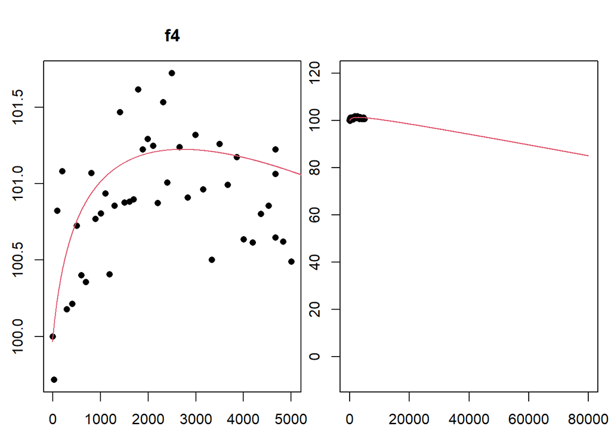

```r
par(mfrow=c(1,2),mar=c(2,2,3,0.25),oma=rep(0.5,4))
plot(t,y,xlab="Hour ", ylab="Intensity(%) ", pch=16,main='f4')
lines(x,y4,col=2)
plot(t,y,xlab="Hour ", ylab="Intensity(%) ", pch=16, xlim = c(-10,80000),ylim = c(-10,120))
lines(x,y4,col=2)
```

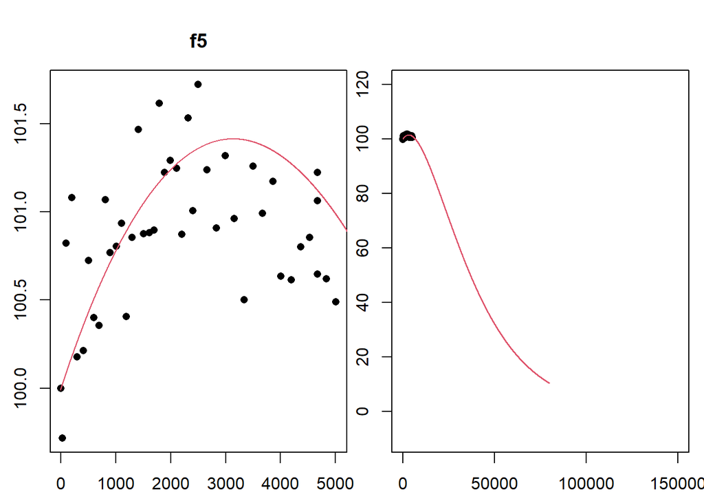

```r
par(mfrow=c(1,2),mar=c(2,2,3,0.25),oma=rep(0.5,4))
plot(t,y,xlab="Hour ", ylab="Intensity(%) ", pch=16,main='f5')
lines(x,y5,col=2)
plot(t,y,xlab="Hour ", ylab="Intensity(%) ", pch=16, xlim = c(-10,150000),ylim = c(-10,120))
lines(x,y5,col=2)
```

We can see on the graph f5 that th light intensity reaches a maximum at around 3000 hours then decreases quickly then at around 50,000 the intensity starts to more slowly decrease. Looking at the slope we can determine that the light bulb reaches the end of its life around 140,000 hours.This means after 15 years light bulbs reach the end of their life on average.